# Bayesian GLM Part4

```r
loyn_brm2 |> get_variables()
```

```
 [1] "b_Intercept"     "b_scalelogDIST"  "b_scalelogLDIST" "b_scalelogAREA"
 [5] "b_fGRAZE2"       "b_fGRAZE3"       "b_fGRAZE4"       "b_fGRAZE5"
 [9] "b_scaleALT"      "b_scaleYR.ISOL"  "sigma"           "Intercept"
[13] "prior_Intercept" "prior_b"         "prior_sigma"     "lprior"
[17] "lp__"            "accept_stat__"   "stepsize__"      "treedepth__"
[21] "n_leapfrog__"    "divergent__"     "energy__"
```

```r
loyn_draw <- loyn_brm2 |> gather_draws(`^b_.*`,  regex = TRUE)
loyn_draw
```

```
# A tibble: 15,000 × 5
# Groups:   .variable [10]
   .chain .iteration .draw .variable   .value
    <int>      <int> <int> <chr>        <dbl>
 1      1          1     1 b_Intercept   3.21
 2      1          2     2 b_Intercept   2.69
 3      1          3     3 b_Intercept   2.94
 4      1          4     4 b_Intercept   3.20
 5      1          5     5 b_Intercept   3.21
 6      1          6     6 b_Intercept   3.22
 7      1          7     7 b_Intercept   3.09
 8      1          8     8 b_Intercept   3.03
 9      1          9     9 b_Intercept   2.90
10      1         10    10 b_Intercept   3.00
# ℹ 14,990 more rows
```

**bayesplot**

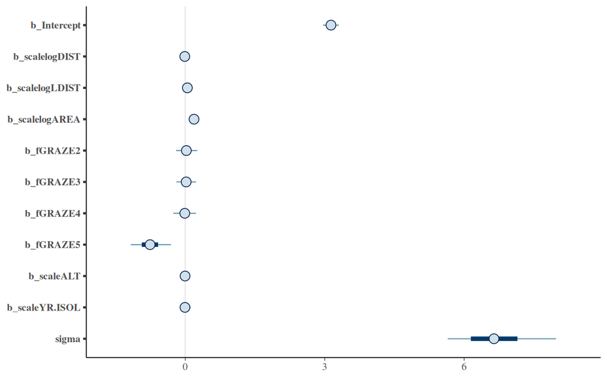

```r
loyn_brm2 |> mcmc_plot(type = 'intervals')
```

**half-eye (ggdist)**

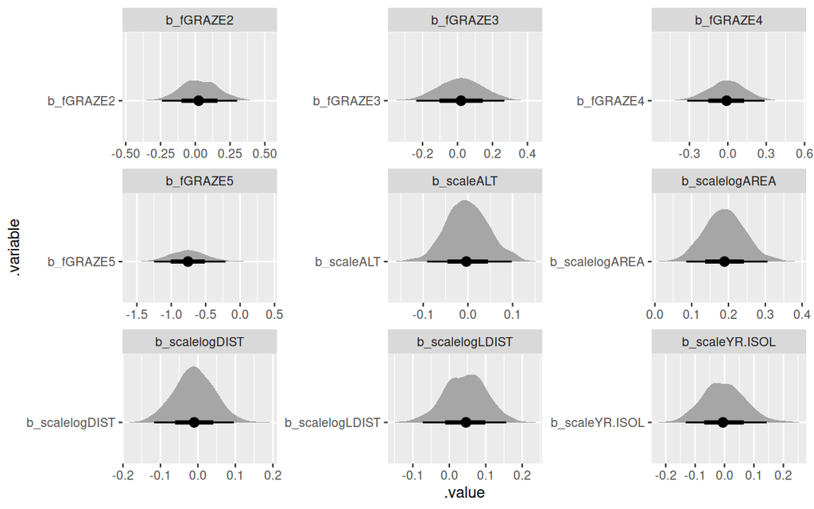

```r
loyn_brm2 |>
    gather_draws(`^b_.*`, regex=TRUE) |>
    filter(.variable != 'b_Intercept') |>
    ggplot() +
    stat_halfeye(aes(x=.value,  y=.variable)) +
    facet_wrap(~.variable, scales='free')
```

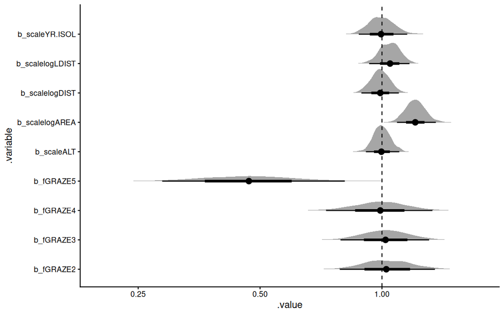

```r
loyn_brm2 |>
  gather_draws(`^b_.*`, regex=TRUE) |>
  mutate(.value = exp(.value)) |>
  filter(.variable != 'b_Intercept') |>
  ggplot() +
  stat_halfeye(aes(x=.value,  y=.variable)) +
  geom_vline(xintercept = 1, linetype = 'dashed') +
  scale_x_continuous(trans = scales::log2_trans()) +
  theme_classic()
```

**density ridges (ggridges)**

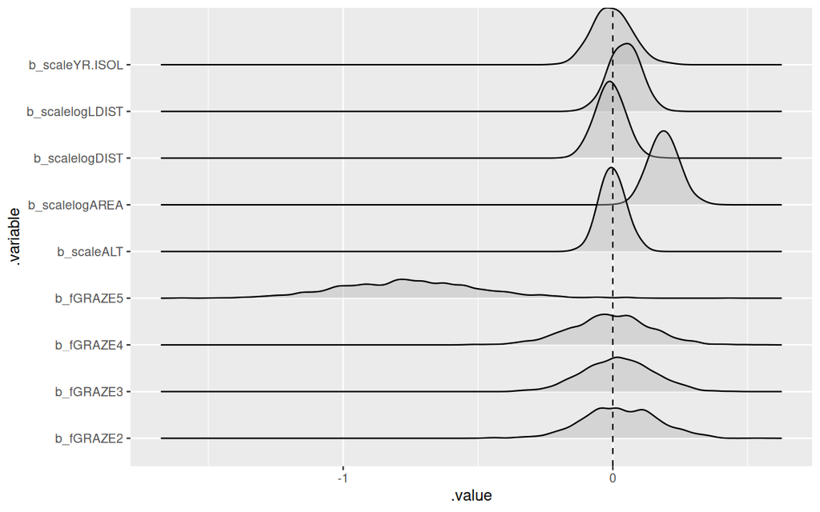

```r
loyn_brm2 |>
    gather_draws(`^b_.*`, regex=TRUE) |>
    filter(.variable != 'b_Intercept') |>
    ggplot() +
    geom_density_ridges(aes(x=.value, y = .variable), alpha=0.4) +
    geom_vline(xintercept = 0, linetype = 'dashed')
```

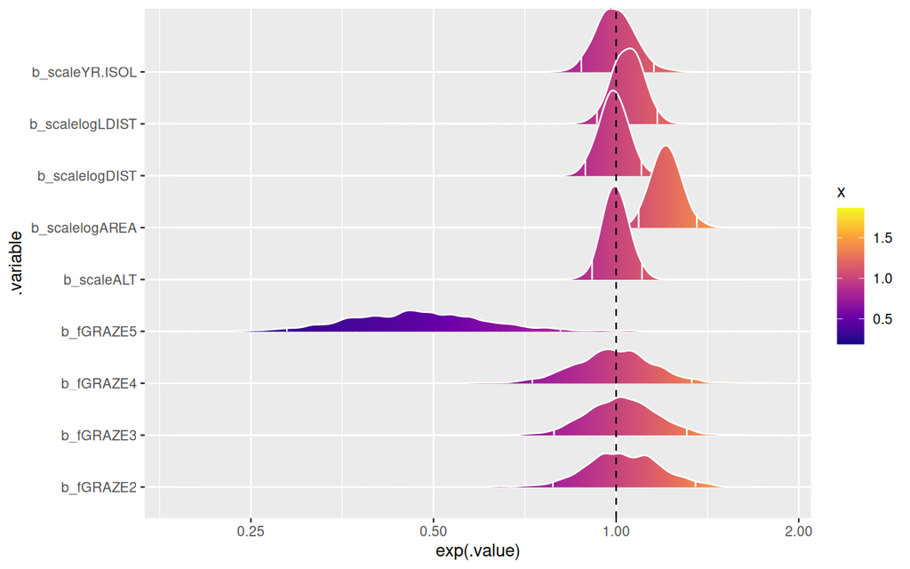

```r
##Or on a fractional scale
loyn_brm2 |>
    gather_draws(`^b_.*`, regex=TRUE) |>
    filter(.variable != 'b_Intercept') |>
    ggplot() +
    geom_density_ridges_gradient(aes(x=exp(.value),
                                     y = .variable,
                                     fill = stat(x)),
                                 alpha=0.4, colour = 'white',
                                 quantile_lines = TRUE,
                                 quantiles = c(0.025, 0.975)) +
    geom_vline(xintercept = 1, linetype = 'dashed') +
    scale_x_continuous(trans = scales::log2_trans()) +
    scale_fill_viridis_c(option = "C")
```

**spread_draws**

```r
loyn_brm2 |> spread_draws(`^b_.*`,  regex = TRUE)
```

```
# A tibble: 1,500 × 13
   .chain .iteration .draw b_Intercept b_scalelogDIST b_scalelogLDIST
    <int>      <int> <int>       <dbl>          <dbl>           <dbl>
 1      1          1     1        3.21      -0.0195            0.0815
 2      1          2     2        2.69       0.000806         -0.0245
 3      1          3     3        2.94       0.0374            0.0725
 4      1          4     4        3.20      -0.0416           -0.0122
 5      1          5     5        3.21       0.0165            0.0709
 6      1          6     6        3.22      -0.102             0.0688
 7      1          7     7        3.09       0.0117            0.0924
 8      1          8     8        3.03       0.0164            0.0243
 9      1          9     9        2.90      -0.0441            0.0933
10      1         10    10        3.00       0.0624           -0.121
# ℹ 1,490 more rows
# ℹ 7 more variables: b_scalelogAREA <dbl>, b_fGRAZE2 <dbl>, b_fGRAZE3 <dbl>,
#   b_fGRAZE4 <dbl>, b_fGRAZE5 <dbl>, b_scaleALT <dbl>, b_scaleYR.ISOL <dbl>
```

**posterior_samples**

```r
loyn_brm2 |> posterior_samples() |> as_tibble()
```

```
# A tibble: 1,500 × 17
   b_Intercept b_scalelogDIST b_scalelogLDIST b_scalelogAREA b_fGRAZE2 b_fGRAZE3
         <dbl>          <dbl>           <dbl>          <dbl>     <dbl>     <dbl>
 1        3.21      -0.0195            0.0815         0.0942   -0.0464  -0.106
 2        2.69       0.000806         -0.0245         0.341     0.285    0.445
 3        2.94       0.0374            0.0725         0.226     0.178    0.212
 4        3.20      -0.0416           -0.0122         0.212    -0.0410   0.0852
 5        3.21       0.0165            0.0709         0.148    -0.0704   0.0339
 6        3.22      -0.102             0.0688         0.154    -0.0203  -0.00114
 7        3.09       0.0117            0.0924         0.180    -0.0850  -0.0179
 8        3.03       0.0164            0.0243         0.236    -0.0203   0.0571
 9        2.90      -0.0441            0.0933         0.269     0.159    0.289
10        3.00       0.0624           -0.121          0.258    -0.0896  -0.0522
# ℹ 1,490 more rows
# ℹ 11 more variables: b_fGRAZE4 <dbl>, b_fGRAZE5 <dbl>, b_scaleALT <dbl>,
#   b_scaleYR.ISOL <dbl>, sigma <dbl>, Intercept <dbl>, prior_Intercept <dbl>,
#   prior_b <dbl>, prior_sigma <dbl>, lprior <dbl>, lp__ <dbl>
```

**\(R^2\)**

```r
loyn_brm2 |> bayes_R2(summary = FALSE) |> median_hdci()
```

```
          y     ymin      ymax .width .point .interval
1 0.6113792 0.491116 0.7002537   0.95 median      hdci
```

**ROPE**

Region of Practical Equivalence

For standardised parameter (negligible effect)

```r
0.1 * sd(log(loyn$ABUND))
```

```
[1] 0.09024351
```

```r
loyn_brm2 |> bayestestR::rope_range()
```

```
[1] -0.01  0.01
```

```r
loyn_brm2 |> bayestestR::rope(range = c(-0.09, 0.09))
```

```
# Proportion of samples inside the ROPE [-0.09, 0.09]:

Parameter     | Inside ROPE
---------------------------
Intercept     |      0.00 %
scalelogDIST  |     94.52 %
scalelogLDIST |     80.06 %
scalelogAREA  |      0.42 %
fGRAZE2       |     48.60 %
fGRAZE3       |     54.49 %
fGRAZE4       |     50.56 %
fGRAZE5       |      0.00 %
scaleALT      |     98.67 %
scaleYR.ISOL  |     83.64 %
```

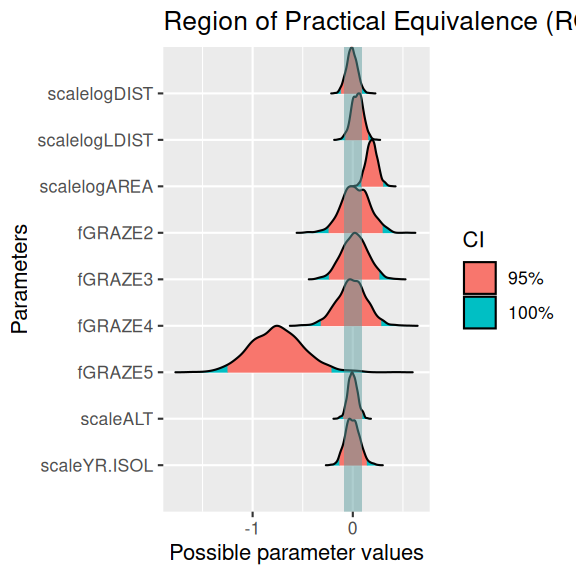

```r
loyn_brm2 |> bayestestR::rope(range = c(-0.09, 0.09)) |>
    plot(data = loyn_brm2)
```

# 10 Further analyses

**Model selection**

**rstanarm**

```r
loyn_rstanarm4a <- update(loyn_rstanarm3,  .~scale(log(DIST))*scale(log(LDIST)),
                          diagnostic_file = file.path(tempdir(), "dfa.csv"))
loyn_rstanarm4b <- update(loyn_rstanarm3,  .~scale(log(AREA)) * fGRAZE,
                          diagnostic_file = file.path(tempdir(), "dfb.csv"))
loyn_rstanarm4c <- update(loyn_rstanarm3,  .~scale(log(AREA)) * fGRAZE * scale(YR.ISOL),
                          diagnostic_file = file.path(tempdir(), "dfc.csv"))
loyn_rstanarm4d <- update(loyn_rstanarm3,  .~scale(ALT),
                          diagnostic_file = file.path(tempdir(), "dfd.csv"))
loyn_rstanarm4e <- update(loyn_rstanarm3,  .~1,
                          diagnostic_file = file.path(tempdir(), "dfe.csv"))
loo_compare(loo(loyn_rstanarm4a),
            loo(loyn_rstanarm4e)
            )
```

```
           model elpd_diff se_diff p_worse diag_diff diag_elpd
 loyn_rstanarm4e       0.0     0.0      NA
 loyn_rstanarm4a      -2.2     1.5    0.93   N < 100
```

```
Diagnostic flags present.
See ?`loo-glossary` (sections `diag_diff` and `diag_elpd`)
or https://mc-stan.org/loo/reference/loo-glossary.html.
```

```r
loo_compare(loo(loyn_rstanarm4b),
            loo(loyn_rstanarm4e)
            )
```

```
           model elpd_diff se_diff p_worse diag_diff       diag_elpd
 loyn_rstanarm4b       0.0     0.0      NA           2 k_psis > 0.69
 loyn_rstanarm4e     -30.1     7.3    1.00   N < 100
```

```
Diagnostic flags present.
See ?`loo-glossary` (sections `diag_diff` and `diag_elpd`)
or https://mc-stan.org/loo/reference/loo-glossary.html.
```

```r
loo_compare(loo(loyn_rstanarm4c),
            loo(loyn_rstanarm4e)
            )
```

```
           model elpd_diff se_diff p_worse diag_diff       diag_elpd
 loyn_rstanarm4c       0.0     0.0      NA           9 k_psis > 0.69
 loyn_rstanarm4e     -21.9     6.9    1.00   N < 100
```

```
Diagnostic flags present.
See ?`loo-glossary` (sections `diag_diff` and `diag_elpd`)
or https://mc-stan.org/loo/reference/loo-glossary.html.
```

```r
loo_compare(loo(loyn_rstanarm4d),
            loo(loyn_rstanarm4e)
            )
```

```
           model elpd_diff se_diff p_worse diag_diff diag_elpd
 loyn_rstanarm4d       0.0     0.0      NA
 loyn_rstanarm4e      -3.5     2.3    0.94   N < 100
```

```
Diagnostic flags present.
See ?`loo-glossary` (sections `diag_diff` and `diag_elpd`)
or https://mc-stan.org/loo/reference/loo-glossary.html.
```

```r
bayes_factor(bridge_sampler(loyn_rstanarm4a),
             bridge_sampler(loyn_rstanarm4e))
```

```
Iteration: 1
Iteration: 2
Iteration: 3
Iteration: 4
Iteration: 5
Iteration: 1
Iteration: 2
Iteration: 3
Iteration: 4
```

```
Estimated Bayes factor in favor of x1 over x2: 0.00136
```

```r
bayes_factor(bridge_sampler(loyn_rstanarm4b),
             bridge_sampler(loyn_rstanarm4e))
```

```
Iteration: 1
Iteration: 2
Iteration: 3
Iteration: 4
Iteration: 5
Iteration: 6
Iteration: 1
Iteration: 2
Iteration: 3
Iteration: 4
```

```
Estimated Bayes factor in favor of x1 over x2: 1095760211.42877
```

```r
bayes_factor(bridge_sampler(loyn_rstanarm4c),
             bridge_sampler(loyn_rstanarm4e))
```

```
Iteration: 1
Iteration: 2
Iteration: 3
Iteration: 4
Iteration: 5
Iteration: 6
Iteration: 1
Iteration: 2
Iteration: 3
Iteration: 4
Iteration: 5
```

```
Estimated Bayes factor in favor of x1 over x2: 7334.76216
```

```r
bayes_factor(bridge_sampler(loyn_rstanarm4d),
             bridge_sampler(loyn_rstanarm4e))
```

```
Iteration: 1
Iteration: 2
Iteration: 3
Iteration: 4
Iteration: 5
Iteration: 6
Iteration: 1
Iteration: 2
Iteration: 3
Iteration: 4
```

```
Estimated Bayes factor in favor of x1 over x2: 4.96806
```

**brm**

```r
loyn_brm3a <- update(loyn_brm2,  .~scale(log(DIST))*scale(log(LDIST)),
                     save_pars = save_pars(all = TRUE), refresh = 0)
loyn_brm3b <- update(loyn_brm2,  .~scale(log(AREA)) * fGRAZE,
                     save_pars = save_pars(all = TRUE), refresh = 0)
loyn_brm3c <- update(loyn_brm2,  .~scale(log(AREA)) * fGRAZE * scale(YR.ISOL),
                     save_pars = save_pars(all = TRUE), refresh = 0)
loyn_brm3d <- update(loyn_brm2,  .~scale(ALT),
                     save_pars = save_pars(all = TRUE), refresh = 0)
loyn_brm3e <- update(loyn_brm2,  .~1,
                     save_pars = save_pars(all = TRUE), refresh = 0)
```

```
The desired updates require recompiling the model
```

```r
waic(loyn_brm3a)
```

```
Computed from 1500 by 56 log-likelihood matrix.

          Estimate  SE
elpd_waic   -217.0 4.5
p_waic         3.8 0.8
waic         434.0 8.9

2 (3.6%) p_waic estimates greater than 0.4. We recommend trying loo instead.
```

```r
loo(loyn_brm3a)
```

```
Computed from 1500 by 56 log-likelihood matrix.

         Estimate  SE
elpd_loo   -217.1 4.5
p_loo         4.0 0.8
looic       434.3 9.0
------
MCSE of elpd_loo is NA.
MCSE and ESS estimates assume MCMC draws (r_eff in [0.8, 1.1]).

Pareto k diagnostic values:
                          Count Pct.    Min. ESS
(-Inf, 0.69]   (good)     55    98.2%   767
   (0.69, 1]   (bad)       1     1.8%   <NA>
    (1, Inf)   (very bad)  0     0.0%   <NA>
See help('pareto-k-diagnostic') for details.
```

```r
loo(loyn_brm3e)
```

```
Computed from 1500 by 56 log-likelihood matrix.

         Estimate  SE
elpd_loo   -215.1 4.5
p_loo         1.2 0.2
looic       430.2 9.0
------
MCSE of elpd_loo is 0.0.
MCSE and ESS estimates assume MCMC draws (r_eff in [1.0, 1.0]).

All Pareto k estimates are good (k < 0.69).
See help('pareto-k-diagnostic') for details.
```

```r
loo_compare(loo(loyn_brm3a),
            loo(loyn_brm3e)
            )
```

```
      model elpd_diff se_diff p_worse diag_diff       diag_elpd
 loyn_brm3e       0.0     0.0      NA
 loyn_brm3a      -2.0     1.2    0.95   N < 100 1 k_psis > 0.69
```

```
Diagnostic flags present.
See ?`loo-glossary` (sections `diag_diff` and `diag_elpd`)
or https://mc-stan.org/loo/reference/loo-glossary.html.
```

```r
loo_compare(loo(loyn_brm3b),
            loo(loyn_brm3e)
            )
```

```
      model elpd_diff se_diff p_worse diag_diff       diag_elpd
 loyn_brm3b       0.0     0.0      NA           2 k_psis > 0.69
 loyn_brm3e     -29.4     7.2    1.00   N < 100
```

```
Diagnostic flags present.
See ?`loo-glossary` (sections `diag_diff` and `diag_elpd`)
or https://mc-stan.org/loo/reference/loo-glossary.html.
```

```r
loo_compare(loo(loyn_brm3b, moment_match = TRUE),
            loo(loyn_brm3e)
            )
```

```
      model elpd_diff se_diff p_worse diag_diff diag_elpd
 loyn_brm3b       0.0     0.0      NA
 loyn_brm3e     -29.4     7.2    1.00   N < 100
```

```
Diagnostic flags present.
See ?`loo-glossary` (sections `diag_diff` and `diag_elpd`)
or https://mc-stan.org/loo/reference/loo-glossary.html.
```

```r
loo_compare(loo(loyn_brm3c, moment_match = TRUE),
            loo(loyn_brm3e)
            )
```

```
      model elpd_diff se_diff p_worse diag_diff       diag_elpd
 loyn_brm3c       0.0     0.0      NA           3 k_psis > 0.69
 loyn_brm3e     -20.2     6.7    1.00   N < 100
```

```
Diagnostic flags present.
See ?`loo-glossary` (sections `diag_diff` and `diag_elpd`)
or https://mc-stan.org/loo/reference/loo-glossary.html.
```

```r
loo_compare(loo(loyn_brm3d),
            loo(loyn_brm3e)
            )
```

```
      model elpd_diff se_diff p_worse diag_diff diag_elpd
 loyn_brm3d       0.0     0.0      NA
 loyn_brm3e      -3.5     2.0    0.96   N < 100
```

```
Diagnostic flags present.
See ?`loo-glossary` (sections `diag_diff` and `diag_elpd`)
or https://mc-stan.org/loo/reference/loo-glossary.html.
```

An alternative is to compute Bayes factors based on **bridge sampling**. Note, this process usually requires far greater number of posterior samples (10x) in order to be stable. It is also advisable to run this multiple times to ensure stability.

It calculates the marginal likelihood of one model in favour of another. The larger the value, the more evidence there is of one model over the other.

```r
bayes_factor(loyn_brm3a,
            loyn_brm3e)
```

```
Iteration: 1
Iteration: 2
Iteration: 3
Iteration: 4
Iteration: 5
Iteration: 6
Iteration: 1
Iteration: 2
Iteration: 3
Iteration: 4
Iteration: 5
```

```
Estimated Bayes factor in favor of loyn_brm3a over loyn_brm3e: 0.00008
```

```r
#OR
bayes_factor(loyn_brm3e,
            loyn_brm3a)
```

```
Iteration: 1
Iteration: 2
Iteration: 3
Iteration: 4
Iteration: 5
Iteration: 1
Iteration: 2
Iteration: 3
Iteration: 4
Iteration: 5
Iteration: 6
```

```
Estimated Bayes factor in favor of loyn_brm3e over loyn_brm3a: 12127.02157
```

```r
bayes_factor(loyn_brm3b,
             loyn_brm3e)
```

```
Iteration: 1
Iteration: 2
Iteration: 3
Iteration: 4
Iteration: 5
Iteration: 1
Iteration: 2
Iteration: 3
Iteration: 4
Iteration: 5
```

```
Estimated Bayes factor in favor of loyn_brm3b over loyn_brm3e: 4746.99048
```

```r
#OR
bayes_factor(loyn_brm3e,
             loyn_brm3b)
```

```
Iteration: 1
Iteration: 2
Iteration: 3
Iteration: 4
Iteration: 5
Iteration: 1
Iteration: 2
Iteration: 3
Iteration: 4
Iteration: 5
Iteration: 6
Iteration: 7
```

```
Estimated Bayes factor in favor of loyn_brm3e over loyn_brm3b: 0.00021
```

```r
bayes_factor(loyn_brm3c,
             loyn_brm3e)
```

```
Iteration: 1
Iteration: 2
Iteration: 3
Iteration: 4
Iteration: 5
Iteration: 6
Iteration: 1
Iteration: 2
Iteration: 3
Iteration: 4
Iteration: 5
```

```
Estimated Bayes factor in favor of loyn_brm3c over loyn_brm3e: 0.00005
```

```r
#OR
bayes_factor(loyn_brm3e,
             loyn_brm3c)
```

```
Iteration: 1
Iteration: 2
Iteration: 3
Iteration: 4
Iteration: 1
Iteration: 2
Iteration: 3
Iteration: 4
Iteration: 5
```

```
Estimated Bayes factor in favor of loyn_brm3e over loyn_brm3c: 18656.56266
```

```r
bayes_factor(loyn_brm3d,
             loyn_brm3e)
```

```
Iteration: 1
Iteration: 2
Iteration: 3
Iteration: 4
Iteration: 5
Iteration: 1
Iteration: 2
Iteration: 3
Iteration: 4
Iteration: 5
Iteration: 6
```

```
Estimated Bayes factor in favor of loyn_brm3d over loyn_brm3e: 1.28335
```

```r
#OR
bayes_factor(loyn_brm3e,
             loyn_brm3d)
```

```
Iteration: 1
Iteration: 2
Iteration: 3
Iteration: 4
Iteration: 1
Iteration: 2
Iteration: 3
Iteration: 4
Iteration: 5
Iteration: 6
```

```
Estimated Bayes factor in favor of loyn_brm3e over loyn_brm3d: 0.77354
```

**Prediction data (newdata)**

**tidyverse (expand)**

Range of AREA crossed with unique fGRAZE levels.

```r
newdata <- loyn |>
    expand(
        AREA = modelr::seq_range(AREA, n = 100),
        fGRAZE = unique(fGRAZE)
    )
newdata |> head()
```

```
# A tibble: 6 × 2
   AREA fGRAZE
  <dbl> <fct>
1   0.1 1
2   0.1 2
3   0.1 3
4   0.1 4
5   0.1 5
6  18.0 1
```

```r
newdata |>
  group_by(fGRAZE) |>
  summarise_draws(range)
```

```
# A tibble: 5 × 4
# Groups:   fGRAZE [5]
  fGRAZE variable range.1 range.2
  <fct>  <chr>      <dbl>   <dbl>
1 1      AREA         0.1    1771
2 2      AREA         0.1    1771
3 3      AREA         0.1    1771
4 4      AREA         0.1    1771
5 5      AREA         0.1    1771
```

Different range of AREA crossed with unique fGRAZE levels.

```r
newdata <- loyn |>
    group_by(fGRAZE) |>
    expand(
        AREA = modelr::seq_range(AREA, n = 100)
    )
newdata |> head()
```

```
# A tibble: 6 × 2
# Groups:   fGRAZE [1]
  fGRAZE  AREA
  <fct>  <dbl>
1 1        2
2 1       19.9
3 1       37.7
4 1       55.6
5 1       73.5
6 1       91.3
```

```r
newdata |>
  group_by(fGRAZE) |>
  summarise_draws(range)
```

```
# A tibble: 5 × 4
# Groups:   fGRAZE [5]
  fGRAZE variable range.1 range.2
  <fct>  <chr>      <dbl>   <dbl>
1 1      AREA         2      1771
2 2      AREA         0.1      96
3 3      AREA         1        48
4 4      AREA         1        19
5 5      AREA         0.5      22
```

**modelr (data_grid)**

Range of AREA crossed with unique fGRAZE levels.

```r
newdata <- loyn |>
    modelr::data_grid(AREA = modelr::seq_range(AREA, 10), fGRAZE)
newdata |> head()
```

```
# A tibble: 6 × 2
   AREA fGRAZE
  <dbl> <fct>
1   0.1 1
2   0.1 2
3   0.1 3
4   0.1 4
5   0.1 5
6 197.  1
```

```r
newdata |>
  group_by(fGRAZE) |>
  summarise_draws(range)
```

```
# A tibble: 5 × 4
# Groups:   fGRAZE [5]
  fGRAZE variable range.1 range.2
  <fct>  <chr>      <dbl>   <dbl>
1 1      AREA         0.1    1771
2 2      AREA         0.1    1771
3 3      AREA         0.1    1771
4 4      AREA         0.1    1771
5 5      AREA         0.1    1771
```

Different range of AREA crossed with unique fGRAZE levels.

```r
newdata <- loyn |>
  group_by(fGRAZE) |>
  modelr::data_grid(AREA = modelr::seq_range(AREA, 10))
newdata |> head()
```

```
# A tibble: 6 × 2
# Groups:   fGRAZE [1]
  fGRAZE  AREA
  <fct>  <dbl>
1 1         2
2 1       199.
3 1       395.
4 1       592.
5 1       788.
6 1       985.
```

```r
newdata |>
  group_by(fGRAZE) |>
  summarise_draws(range)
```

```
# A tibble: 5 × 4
# Groups:   fGRAZE [5]
  fGRAZE variable range.1 range.2
  <fct>  <chr>      <dbl>   <dbl>
1 1      AREA         2      1771
2 2      AREA         0.1      96
3 3      AREA         1        48
4 4      AREA         1        19
5 5      AREA         0.5      22
```

**marginaleffects (datagrid)**

Range of AREA crossed with unique fGRAZE levels.

```r
newdata <-
    marginaleffects::datagrid(
      newdata = loyn,
      AREA = function(x) modelr::seq_range(x, n = 100),
      fGRAZE = unique
    )
newdata |> head()
```

```
  rowid    ABUND YR.ISOL DIST LDIST GRAZE ALT     AREA fGRAZE
1     1 19.51429    1950  240   733     3 146  0.10000      1
2     2 19.51429    1950  240   733     3 146  0.10000      2
3     3 19.51429    1950  240   733     3 146  0.10000      3
4     4 19.51429    1950  240   733     3 146  0.10000      4
5     5 19.51429    1950  240   733     3 146  0.10000      5
6     6 19.51429    1950  240   733     3 146 17.98788      1
```

```r
newdata |>
  group_by(fGRAZE) |>
  dplyr::select(AREA) |>
  summarise_draws(range)
```

```
# A tibble: 5 × 4
# Groups:   fGRAZE [5]
  fGRAZE variable range.1 range.2
  <fct>  <chr>      <dbl>   <dbl>
1 1      AREA         0.1    1771
2 2      AREA         0.1    1771
3 3      AREA         0.1    1771
4 4      AREA         0.1    1771
5 5      AREA         0.1    1771
```

Different range of AREA crossed with unique fGRAZE levels.

```r
newdata <-
    marginaleffects::datagrid(
      newdata = loyn,
      AREA = function(x) modelr::seq_range(x, n = 100),
      by = "fGRAZE",
      grid_type = "balanced"
    )
newdata |> head()
```

```
  rowid    ABUND YR.ISOL DIST LDIST GRAZE ALT fGRAZE     AREA
1     1 28.62308    1963  432  1079     1 162      1  2.00000
2     2 28.62308    1963  432  1079     1 162      1 19.86869
3     3 28.62308    1963  432  1079     1 162      1 37.73737
4     4 28.62308    1963  432  1079     1 162      1 55.60606
5     5 28.62308    1963  432  1079     1 162      1 73.47475
6     6 28.62308    1963  432  1079     1 162      1 91.34343
```

```r
newdata |>
  group_by(fGRAZE) |>
  dplyr::select(AREA) |>
  summarise_draws(range)
```

```
# A tibble: 5 × 4
# Groups:   fGRAZE [5]
  fGRAZE variable range.1 range.2
  <fct>  <chr>      <dbl>   <dbl>
1 1      AREA         2      1771
2 2      AREA         0.1      96
3 3      AREA         1        48
4 4      AREA         1        19
5 5      AREA         0.5      22
```

```r
## or with the model instead of the raw data
newdata <-
    marginaleffects::datagrid(
      model = loyn_brm3b,
      AREA = function(x) modelr::seq_range(x, n = 100),
      by = "fGRAZE",
      grid_type = "balanced"
    )
newdata |> head()
```

```
  rowid fGRAZE     AREA
1     1      1  2.00000
2     2      1 19.86869
3     3      1 37.73737
4     4      1 55.60606
5     5      1 73.47475
6     6      1 91.34343
```

```r
newdata |>
  group_by(fGRAZE) |>
  dplyr::select(AREA) |>
  summarise_draws(range)
```

```
# A tibble: 5 × 4
# Groups:   fGRAZE [5]
  fGRAZE variable range.1 range.2
  <fct>  <chr>      <dbl>   <dbl>
1 1      AREA         2      1771
2 2      AREA         0.1      96
3 3      AREA         1        48
4 4      AREA         1        19
5 5      AREA         0.5      22
```

**Contrasts**

**brms**

Compare effect of grazing at different patch areas

```r
loyn_list <- with(loyn, list(AREA = c(min(AREA), mean(AREA), max(AREA))))

loyn_brm3b |>
    emmeans(~fGRAZE|AREA, at = loyn_list, type = "response") |>
    pairs(reverse = FALSE)
```

```
AREA = 0.1:
 contrast          ratio lower.HPD upper.HPD
 fGRAZE1 / fGRAZE2 1.903   0.87137     3.496
 fGRAZE1 / fGRAZE3 2.059   0.81267     3.667
 fGRAZE1 / fGRAZE4 6.922   0.67936    31.899
 fGRAZE1 / fGRAZE5 4.449   1.32384    10.283
 fGRAZE2 / fGRAZE3 1.076   0.41732     2.012
 fGRAZE2 / fGRAZE4 3.533   0.38246    18.141
 fGRAZE2 / fGRAZE5 2.301   0.61434     5.873
 fGRAZE3 / fGRAZE4 3.372   0.36840    17.021
 fGRAZE3 / fGRAZE5 2.191   0.48861     5.302
 fGRAZE4 / fGRAZE5 0.658   0.01867     2.645

AREA = 69.2696428571429:
 contrast          ratio lower.HPD upper.HPD
 fGRAZE1 / fGRAZE2 0.913   0.71245     1.149
 fGRAZE1 / fGRAZE3 0.867   0.66002     1.134
 fGRAZE1 / fGRAZE4 0.547   0.24678     0.968
 fGRAZE1 / fGRAZE5 1.636   0.76010     3.535
 fGRAZE2 / fGRAZE3 0.950   0.69292     1.285
 fGRAZE2 / fGRAZE4 0.601   0.27968     1.092
 fGRAZE2 / fGRAZE5 1.819   0.72262     3.838
 fGRAZE3 / fGRAZE4 0.632   0.23976     1.123
 fGRAZE3 / fGRAZE5 1.901   0.68331     4.015
 fGRAZE4 / fGRAZE5 3.016   0.91428     7.535

AREA = 1771:
 contrast          ratio lower.HPD upper.HPD
 fGRAZE1 / fGRAZE2 0.632   0.34130     1.037
 fGRAZE1 / fGRAZE3 0.565   0.26109     0.974
 fGRAZE1 / fGRAZE4 0.156   0.00504     0.621
 fGRAZE1 / fGRAZE5 1.019   0.13520     3.983
 fGRAZE2 / fGRAZE3 0.904   0.36895     1.700
 fGRAZE2 / fGRAZE4 0.247   0.00877     1.032
 fGRAZE2 / fGRAZE5 1.589   0.18471     6.736
 fGRAZE3 / fGRAZE4 0.275   0.00702     1.157
 fGRAZE3 / fGRAZE5 1.782   0.11530     7.895
 fGRAZE4 / fGRAZE5 6.513   0.20593    51.382

Point estimate displayed: median
Results are back-transformed from the log scale
HPD interval probability: 0.95
```

```r
newdata <- loyn_brm3b |>
    emmeans(~fGRAZE|AREA, at = loyn_list, type = 'response') |>
    pairs() |>
    as.data.frame()
head(newdata)
```

```
 contrast          AREA    ratio lower.HPD upper.HPD
 fGRAZE1 / fGRAZE2 0.1  1.902674 0.8713736   3.49563
 fGRAZE1 / fGRAZE3 0.1  2.058694 0.8126721   3.66743
 fGRAZE1 / fGRAZE4 0.1  6.921960 0.6793581  31.89858
 fGRAZE1 / fGRAZE5 0.1  4.449167 1.3238380  10.28252
 fGRAZE2 / fGRAZE3 0.1  1.076436 0.4173181   2.01241
 fGRAZE2 / fGRAZE4 0.1  3.533092 0.3824573  18.14098

Point estimate displayed: median
Results are back-transformed from the log scale
HPD interval probability: 0.95
```

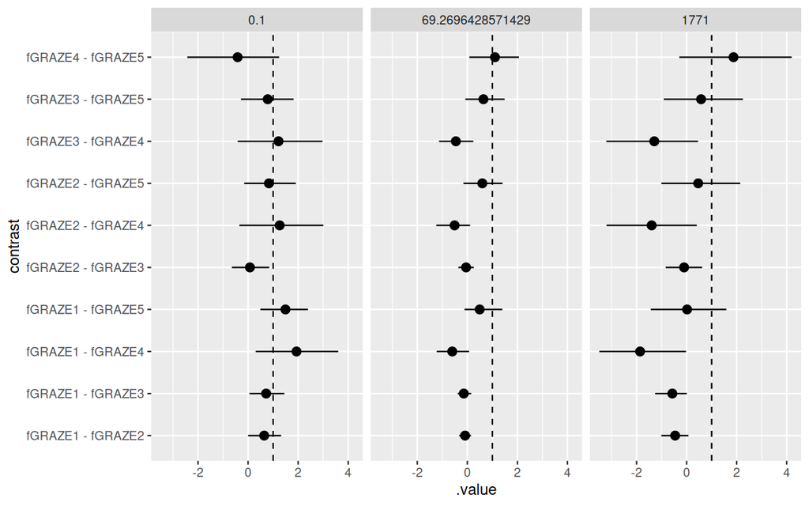

```r
newdata <- loyn_brm3b |>
    emmeans(~fGRAZE|AREA, at = loyn_list, type = 'response') |>
    pairs() |>
    gather_emmeans_draws()
newdata |> median_hdci() |>
    ggplot() +
    geom_hline(yintercept = 1, linetype = 'dashed') +
    geom_pointrange(aes(y = .value, ymin = .lower, ymax = .upper, x = contrast)) +
    facet_wrap(~AREA) +
    coord_flip()
```

```r
loyn_brm3b |>
    emmeans(~fGRAZE|AREA, at = loyn_list, type = 'response') |>
    gather_emmeans_draws()
```

```
# A tibble: 22,500 × 6
# Groups:   fGRAZE, AREA [15]
   fGRAZE  AREA .chain .iteration .draw .value
   <fct>  <dbl>  <int>      <int> <int>  <dbl>
 1 1        0.1     NA         NA     1   3.27
 2 1        0.1     NA         NA     2   2.59
 3 1        0.1     NA         NA     3   2.92
 4 1        0.1     NA         NA     4   3.23
 5 1        0.1     NA         NA     5   3.06
 6 1        0.1     NA         NA     6   2.97
 7 1        0.1     NA         NA     7   2.61
 8 1        0.1     NA         NA     8   2.97
 9 1        0.1     NA         NA     9   3.15
10 1        0.1     NA         NA    10   3.08
# ℹ 22,490 more rows
```

```r
newdata.p <- newdata |> summarise(P = mean(.value>1))
```

```
`summarise()` has regrouped the output.
ℹ Summaries were computed grouped by contrast and AREA.
ℹ Output is grouped by contrast.
ℹ Use `summarise(.groups = "drop_last")` to silence this message.
ℹ Use `summarise(.by = c(contrast, AREA))` for per-operation grouping
  (`?dplyr::dplyr_by`) instead.
```

```r
g <- newdata |>
    ggplot() +
    geom_vline(xintercept = 1, linetype = 'dashed') +
    stat_slab(aes(x  =  .value, y = contrast,
                  fill = stat(ggdist::cut_cdf_qi(cdf,
                           .width = c(0.5, 0.8, 0.95),
                           labels = scales::percent_format())
                           )), color = 'black') +
    scale_fill_brewer('Interval', direction = -1, na.translate = FALSE) +
    facet_grid(~round(AREA,1))
```

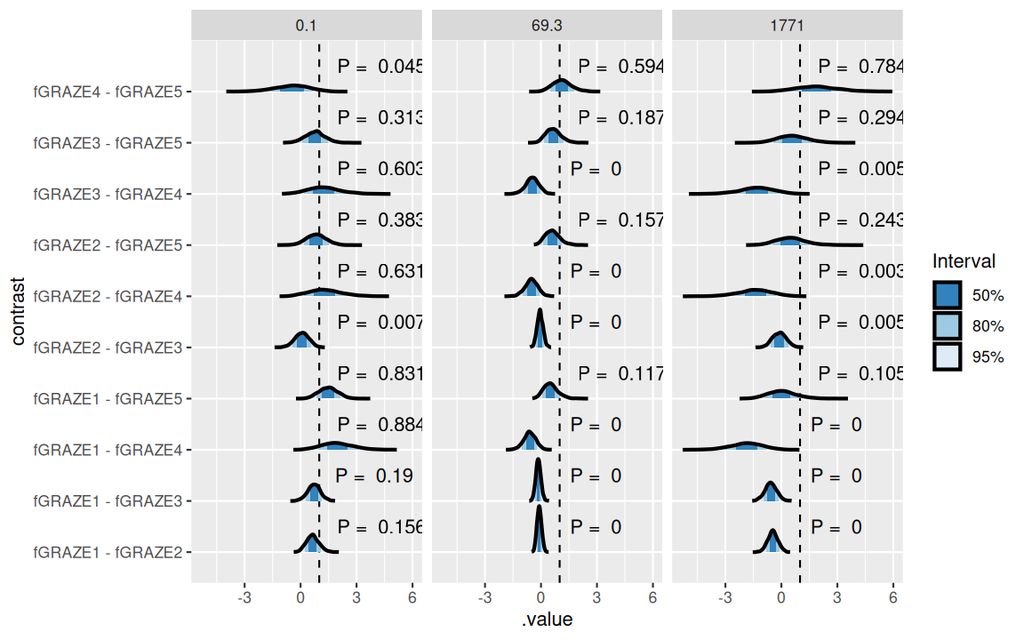

```r
g + geom_text(data = newdata.p, aes(y = contrast, x = 1, label = paste('P = ',round(P,3))), hjust = -0.2, position = position_nudge(y = 0.5))
```

# 11 Summary figure

**rstanarm**

**From the full model**

```r
loyn_list <- with(loyn, list(AREA = modelr::seq_range(AREA, n=100)))

newdata <- emmeans(loyn_brm2, ~AREA|fGRAZE, at = loyn_list, type='response') |>
    as.data.frame()
head(newdata)
```

```
     AREA fGRAZE response lower.HPD upper.HPD
  0.10000 1      15.00601   9.67561  22.10116
 17.98788 1      25.28903  20.99853  30.03269
 35.87576 1      27.11260  23.10580  31.84990
 53.76364 1      28.22395  24.17806  32.93205
 71.65152 1      29.08442  25.14280  33.91125
 89.53939 1      29.78139  25.62907  34.45875

Point estimate displayed: median
Results are back-transformed from the log scale
HPD interval probability: 0.95
```

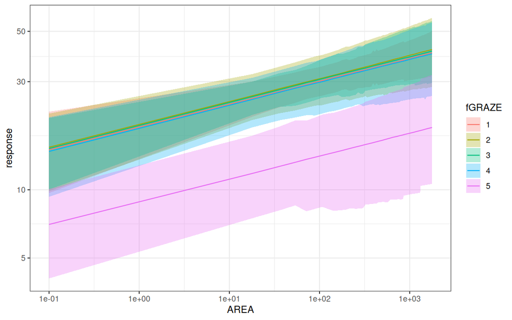

```r
ggplot(newdata, aes(y=response, x=AREA)) +
  geom_ribbon(aes(ymin=lower.HPD, ymax=upper.HPD, fill=fGRAZE), alpha=0.3) +
  geom_line(aes(color=fGRAZE)) +
  theme_bw() +
  scale_x_log10() +
  scale_y_log10()
```

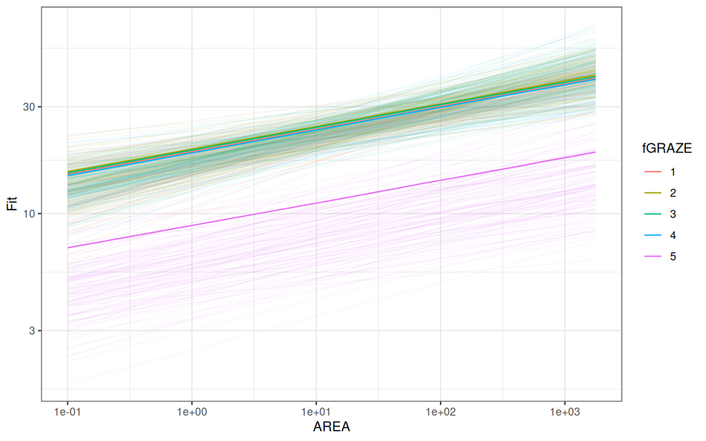

```r
spaghetti = emmeans(loyn_rstanarm3, ~AREA|fGRAZE, at = loyn_list, type='response') |>
  gather_emmeans_draws() |>
  mutate(Fit=exp(.value))
wch = sample(1:max(spaghetti$.draw), 100,replace=FALSE)
spaghetti = spaghetti |>
  filter(.draw %in% wch)
ggplot(newdata) +
  geom_line(data=spaghetti, aes(y=Fit, x=AREA, color=fGRAZE,
                                group=interaction(fGRAZE,.draw)), alpha=0.05) +
  geom_line(aes(y=response, x=AREA, color=fGRAZE)) +
  theme_bw() +
  scale_x_log10() + scale_y_log10()
```

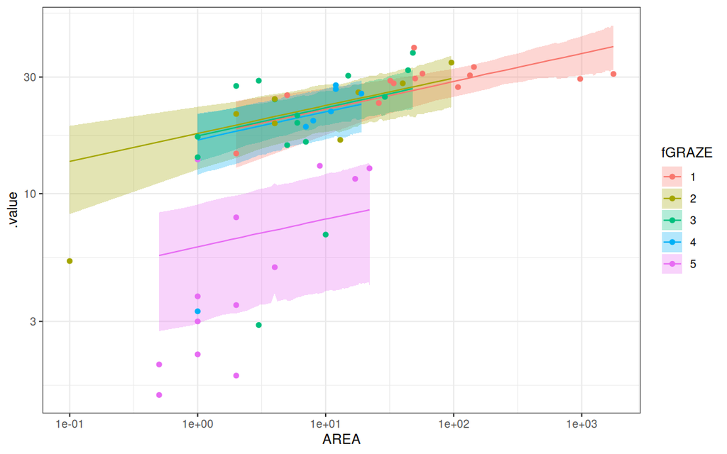

```r
## or honouring the data range
loyn_nd <- loyn |>
    group_by(fGRAZE) |>
    tidyr::expand(AREA = modelr::seq_range(AREA, n=100),
           DIST = mean(DIST), LDIST = mean(LDIST), ALT = mean(ALT), YR.ISOL = mean(YR.ISOL))
loyn_rstanarm3 |>
    epred_draws(newdata = loyn_nd, value = '.value') |>
    median_hdci() |>
    ggplot(aes(x = AREA, y = .value, colour = fGRAZE, fill = fGRAZE)) +
    geom_ribbon(aes(ymin = .lower, ymax = .upper), colour = NA, alpha = 0.3) +
    geom_line() +
    geom_point(data = loyn, aes(y = ABUND, x = AREA)) +
    scale_y_log10() +
    scale_x_log10() +
    theme_bw()
```

**From the “habitat” model**